# C11 Computing Notes

```r
library("AppliedPredictiveModeling")
library("caret"); library("klaR"); library("MASS")
library("pROC"); library("randomForest")
library("doMC")
registerDoMC(cores = 4)
```

```r
set.seed(975)
simulatedTrain <- quadBoundaryFunc(500)
simulatedTest <- quadBoundaryFunc(1000)
head(simulatedTrain)
```

```
##           X1          X2      prob  class
## 1  2.4685709  2.28742015 0.9647251 Class1
## 2 -0.1889407 -1.63949455 0.9913938 Class1
## 3 -1.9101460 -2.89194964 1.0000000 Class1
## 4  0.3481279  0.06707434 0.1529697 Class1
## 5  0.1401153  0.86900555 0.5563062 Class1
## 6  0.7717148 -0.91504835 0.2713248 Class2
```

Lets use a random forest and quadratic discriminant model to fit the data

```r
# mtry will take the default
# for classification is sqrt(p), for regression in p/3
# where p is number of predictors
rfModel <- randomForest(class ~ X1 + X2,
                       data = simulatedTrain,
                       ntree = 2000)

qdaModel <- qda(class ~ X1 + X2, data = simulatedTrain)
```

For QDA, the output of the preict function for qda objects includes both the predicted classes (in a slot called class), and the associated probabilities are in a matrix called posterior

```r
# get predictions on training and test samples
qdaTrainPred <- predict(qdaModel, simulatedTrain)
qdaTestPred <- predict(qdaModel, simulatedTest)

# have a quick nose
names(qdaTrainPred)
```

```
## [1] "class"     "posterior"
```

```r
head(qdaTrainPred$class)
```

```
## [1] Class1 Class1 Class1 Class2 Class1 Class2
## Levels: Class1 Class2
```

```r
head(qdaTrainPred$posterior)
```

```
##      Class1      Class2
## 1 0.7313136 0.268686374
## 2 0.8083861 0.191613899
## 3 0.9985019 0.001498068
## 4 0.3549247 0.645075330
## 5 0.5264952 0.473504846
## 6 0.3604055 0.639594534
```

```r
# extract probabilities
simulatedTrain$QDAprob <- qdaTrainPred$posterior[, "Class1"]
simulatedTest$QDAprob <- qdaTestPred$posterior[, "Class1"]
```

The random forest model requires two calls to the predict function to get the predicted class and class probabilities:

```r
# just for the test set here
rfTestPred <- predict(rfModel, simulatedTest, type = "prob")
head(rfTestPred)
```

```
##   Class1 Class2
## 1 0.4300 0.5700
## 2 0.5185 0.4815
## 3 0.9970 0.0030
## 4 0.9395 0.0605
## 5 0.0205 0.9795
## 6 0.2840 0.7160
```

```r
simulatedTest$RFprob <- rfTestPred[, "Class1"]
simulatedTest$RFclass <- predict(rfModel, simulatedTest)
```

## Sensitivity and Specificity

the caret package has function for sensitivity and specificity. These functions require the user to indicate the role of interest in each of the classes:

```r
# Class 1 is class of interest
sensitivity(data = simulatedTest$RFclass,
            reference = simulatedTest$class,
            positive = "Class1")
```

```
## [1] 0.8278867
```

```r
specificity(data = simulatedTest$RFclass,
            reference = simulatedTest$class,
            positive = "Class1")
```

```
## [1] 0.8946396
```

Predicctive values can also be computed either using the prevalence in the data set or by using prior judgement:

```r
# prevalence in data set is 46%
sum(simulatedTest$class == "Class1") / nrow(simulatedTest)
```

```
## [1] 0.459
```

```r
posPredValue(data = simulatedTest$RFclass,
             reference = simulatedTest$class,
             positive = "Class1")
```

```
## [1] 0.8695652
```

```r
negPredValue(data = simulatedTest$RFclass,
             reference = simulatedTest$class,
             positive = "Class2")
```

[output not shown]

```r
# change the prevalence manually
posPredValue(data = simulatedTest$RFclass,
             reference = simulatedTest$class,
             positive = "Class1",
             prevalence = 0.9)
```

```
## [1] 0.9860567
```

## Confusion Matrix

The confusionMatrix function in the caret package produces the tavle and associated statistics:

```r
confusionMatrix(data = simulatedTest$RFclass,
                reference = simulatedTest$class,
                positive = "Class1")
```

```
## Confusion Matrix and Statistics
##
##           Reference
## Prediction Class1 Class2
##     Class1    380     57
##     Class2     79    484
##
##                Accuracy : 0.864
##                  95% CI : (0.8412, 0.8846)
##     No Information Rate : 0.541
##     P-Value [Acc > NIR] : < 2e-16
##
##                   Kappa : 0.7252
##  Mcnemar's Test P-Value : 0.07174
##
##             Sensitivity : 0.8279
##             Specificity : 0.8946
##          Pos Pred Value : 0.8696
##          Neg Pred Value : 0.8597
##              Prevalence : 0.4590
##          Detection Rate : 0.3800
##    Detection Prevalence : 0.4370
##       Balanced Accuracy : 0.8613
##
##        'Positive' Class : Class1
##
```

There is an option in confusionMatrix to manually set the prevalence. If there are more than two classes, the sensitivity, specififity and similar statitsics are calalculated on a one-vs-all basis (eg the first class versus a pool of classes two and three).

## ROC Curves

The pROC package can create the curve and deive various stattistics. First, an R object must be created that contains the relevant information using the pROC function roc()

```r
rocCurveRF <- roc(response = simulatedTest$class,
                predictor = simulatedTest$RFprob,
                # this function assumes that the second
                # class is the event of interest, so we
                # reverse the labels
                levels = rev(levels(simulatedTest$class)))

rocCurveQDA <- roc(response = simulatedTest$class,
                predictor = simulatedTest$QDAprob,
                # this function assumes that the second
                # class is the event of interest, so we
                # reverse the labels
                levels = rev(levels(simulatedTest$class)))

# can produce statistics
auc(rocCurveRF)
```

```
## Area under the curve: 0.9328
```

```r
ci(rocCurveRF)
```

```
## 95% CI: 0.9176-0.948 (DeLong)
```

```r
# by defailut the x-axis goes backwards
# use the legacy.axes = TRUE to get 1-spec on the x-axis
plot(rocCurveRF, legacy.axes = TRUE)
```

```
##
## Call:
## roc.default(response = simulatedTest$class, predictor = simulatedTest$RFprob,     levels = rev(levels(simulatedTest$class)))
##
## Data: simulatedTest$RFprob in 541 controls (simulatedTest$class Class2) < 459 cases (simulatedTest$class Class1).
## Area under the curve: 0.9328
```

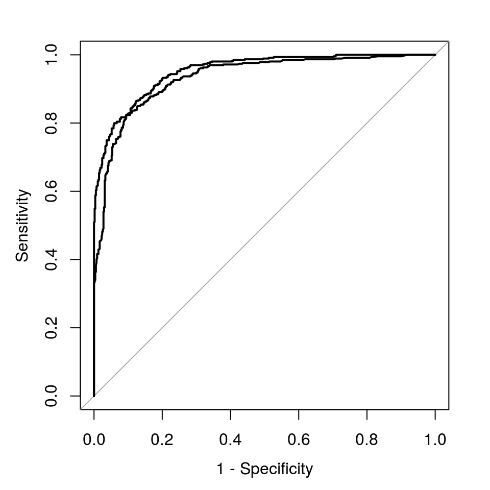

```
##
## Call:
## roc.default(response = simulatedTest$class, predictor = simulatedTest$QDAprob,     levels = rev(levels(simulatedTest$class)))
##
## Data: simulatedTest$QDAprob in 541 controls (simulatedTest$class Class2) < 459 cases (simulatedTest$class Class1).
## Area under the curve: 0.9524
```

```r
# can also add another curve by using add = TRUE next time plot.auc is used
plot(rocCurveQDA, legacy.axes = TRUE, add = T)
```

## Lift Charts

The lift curve can be created using the lift functoin in the caret package. It takes a formula as the input where the true class is on the LHS, and one or more columns for the model class probabilities on the right

```r
labs <- c(RFprob = "Random Forest",
          QDAprob = "QDA")
liftCurve <- lift(class ~ RFprob + QDAprob, data = simulatedTest,
                  labels = labs)
liftCurve
```

```
##
## Call:
## lift.formula(x = class ~ RFprob + QDAprob, data = simulatedTest, labels
##  = labs)
##
## Models: Random Forest, QDA
## Event: Class1 (45.9%)
```

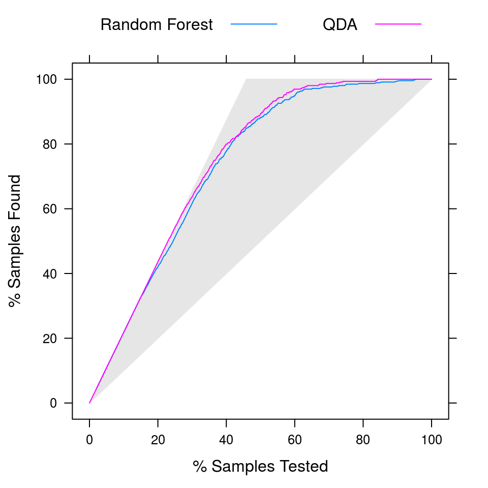

```r
xyplot(liftCurve,
       auto.key = list(columns = 2,
                       lines = T,
                       points = F))
```

## Calibrating Probabilities

Calibrartion plots can be made using the caret function calibration()

```r
calCurve <- calibration(class ~ RFprob + QDAprob, data = simulatedTest)
calCurve
```

```
##
## Call:
## calibration.formula(x = class ~ RFprob + QDAprob, data = simulatedTest)
##
## Models: RFprob, QDAprob
## Event:  Class1
## Cuts: 11
```

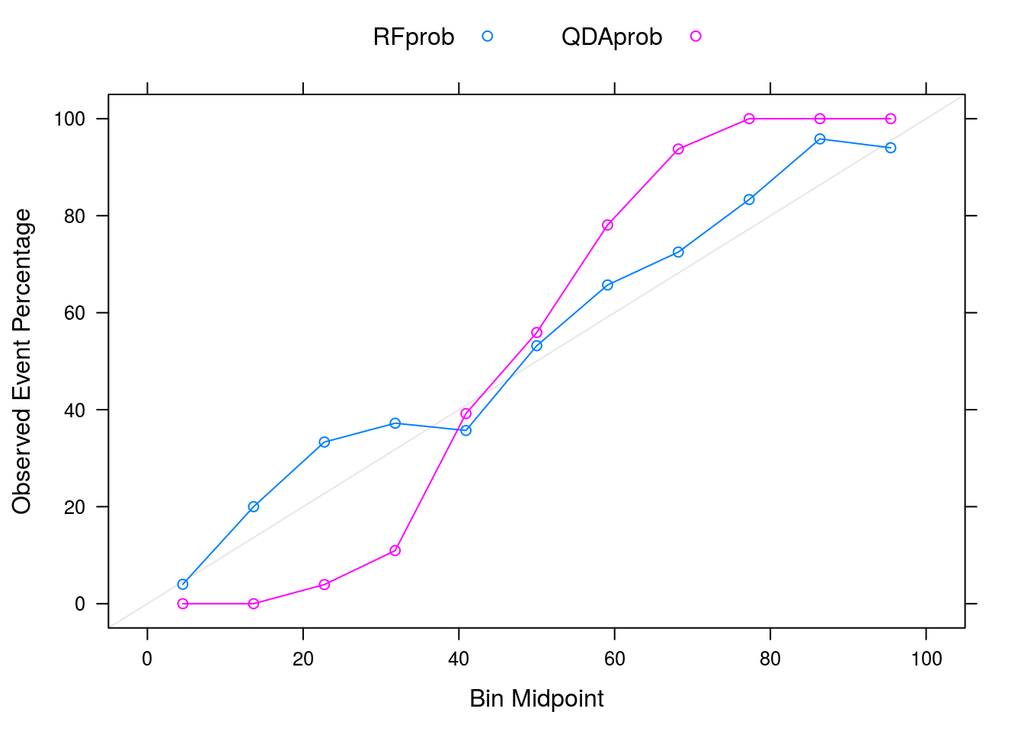

```r
xyplot(calCurve,
       auto.key = list(columns = 2))
```

From the calibration plot, we see that we may want to recalibrate (especially for QDA). To fit a sigmoidal function, a logistic regression model can be used.

```r
# glm function from base R. Select familiy = binary as two class problem
sigmoidalCal <- glm(relevel(class, ref = "Class2") ~ QDAprob,
                    data = simulatedTrain,
                    family = binomial)
coef(summary(sigmoidalCal))
```

```
##              Estimate Std. Error   z value     Pr(>|z|)
## (Intercept) -5.701055  0.5005652 -11.38924 4.731132e-30
## QDAprob     11.717292  1.0705197  10.94542 6.989017e-28
```

We can then obtain the corrected probailities by taking the origional model and applying the correction with the estimated slope and intercept (see notes)

$\hat{p}^\ast = \frac{1}{1 + \exp(-\beta_0 - \beta_1 \hat{p})}$

```r
sigmoidProbs <- predict(sigmoidalCal,
                        newdata = simulatedTest[, "QDAprob", drop = F],
                        type = "response")

simulatedTest$QDAsigmoid <- sigmoidProbs
```

The Bayesian approach can be used as well (will learn about this in later chapters). Can use the NaiveBayes in the klaR package:

```r
# the option usekernel = TRUE allows a flexible function to model
# the probability distribution of the class probs
BayesCal <- NaiveBayes(class ~ QDAprob,
                       data = simulatedTrain,
                       usekernel = TRUE)
# Like qda() the predict function for this model creates both
# the classes and probabilities

BayesProbs <- predict(BayesCal,
                      newdata = simulatedTest[, "QDAprob", drop = F])
simulatedTest$QDABayes <- BayesProbs$posterior[, "Class1"]

# look before and after calibration
head(simulatedTest[, c(5:6, 8, 9)])
```

```
##     QDAprob RFprob QDAsigmoid  QDABayes
## 1 0.3830767 0.4300 0.22927068 0.2515696
## 2 0.5440393 0.5185 0.66231139 0.6383383
## 3 0.9846107 0.9970 0.99708776 0.9995061
## 4 0.5463540 0.9395 0.66835048 0.6430232
## 5 0.2426705 0.0205 0.05428903 0.0566883
## 6 0.4823296 0.2840 0.48763794 0.5109129
```

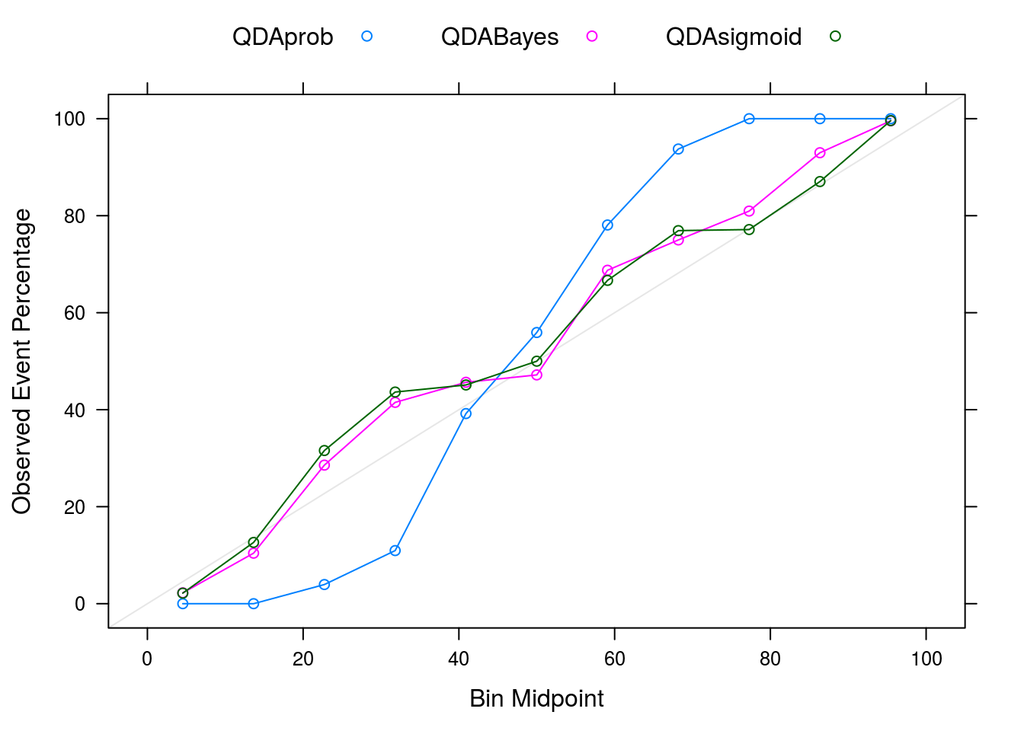

```r
# another plot:
calCurve2 <- calibration(class ~ QDAprob + QDABayes + QDAsigmoid,
                         data = simulatedTest)
xyplot(calCurve2,
       auto.key = list(columns = 3))
```